# My SpotifyR Rubel report

Author

Isadora Zuffo

# Rubel,

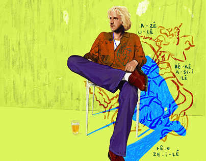

## the one who steals hearts.

> “*A gente sente o gosto de ser brasileiro a partir das palavras que a gente aprende a cantar*”  
> ― *Rubel, 2023*

> [*we feel the taste of being Brazilian from the words we learn to sing*]

## His albums

[figure not shown]

Pearl (2015)

###### debut album, melody and lyrics bringing melancholy and nostalgia about places and loved ones. written in the U.S. in a house shared with other artists and musicians, where he unveiled his passion for composition. creative experimentation and great sensitiveness paved the way to a critically-acclaimed album, an ever-growing craftsman of words and chords was born.

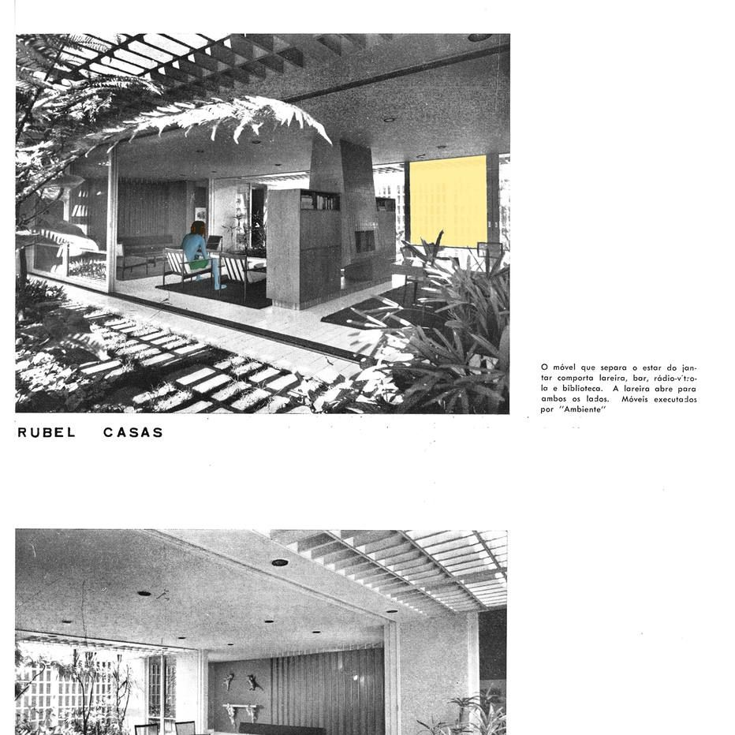

Casas (2018)

###### in his second album, rubel started to experiment with other genres by collaborating with different artists. he steps out of his comfort zone and explores other traditional and contemporary genres of brazilian popular music.

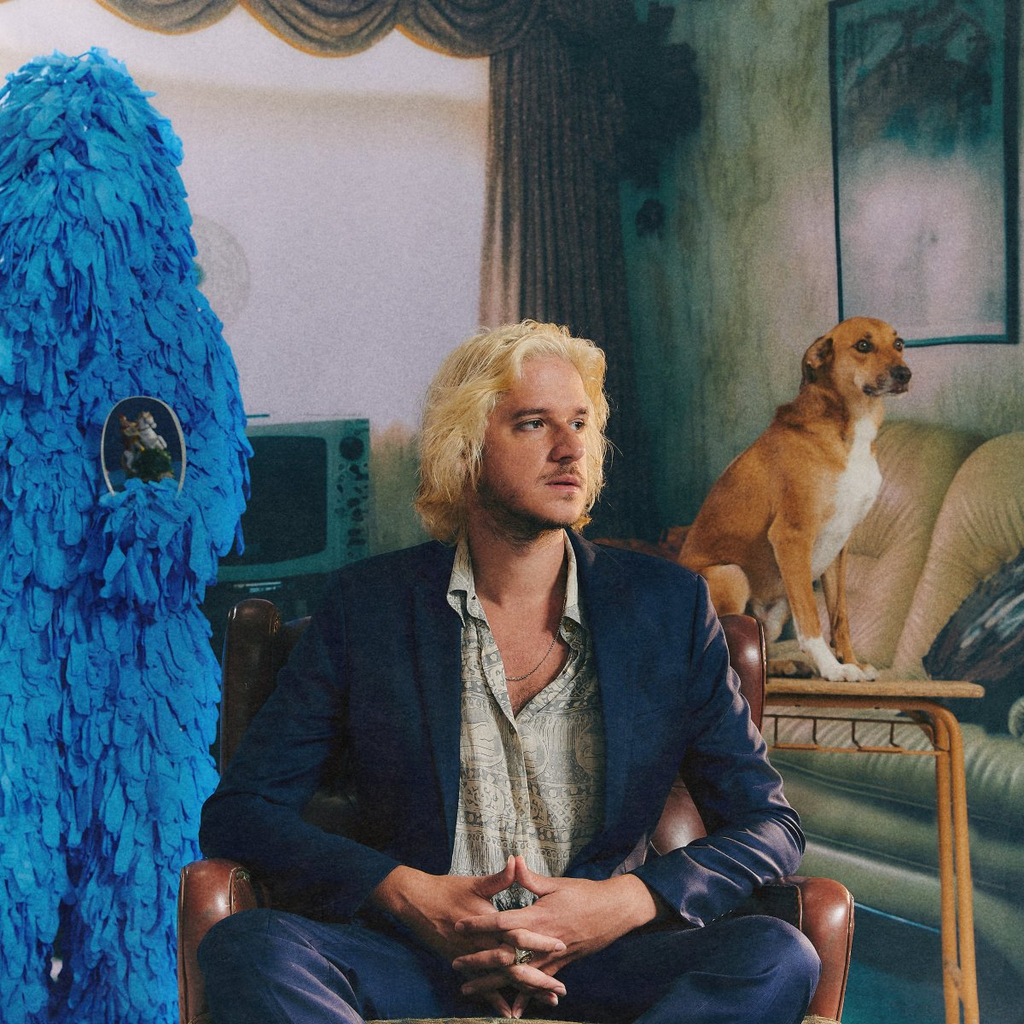

AS PALAVRAS, VOL 1. & 2. (2023)

###### at first, confusing. giving a second chance, you may find an encyclopedia of what brazilian music has best to offer. masters of different genres come together to sing their lungs out, or perhaps give a good dose of sarcasm. politics takes up space, and condemns never-ending social injustices so prevalent in brazilian societ(ies).

## His masterpiece

[Quando Bate Aquela Saudade (2015, Pearl) [When that saudade comes]](https://www.youtube.com/watch?v=tMWpm_GOLaA)

> **Saudade**

> [sau·da·di]\ *noun.*

> **feeling of longing, melancholy, desire, and nostalgia** that is characteristic of the Brazilian or Portuguese temperament. It describes a deep emotional state; a yearning for a happiness that has passed, or perhaps never even existed.

> ― *Oxford Dictionary*

[video not shown]

## Data Analysis

### Data Source

I extracted the data using the `spotifyr` package, and stored it in the data folder.

### Import Data

```r
# These are packages I need for the analysis
library(ggplot2)
library(dplyr)

# Import data into df
df <- read.csv("dataRubel.csv")
```

### How the Data Looks

```r
# Slice 5 random records in the dataframe
df |> dplyr::slice_sample(n=5) |> knitr::kable(digits = 2)
```

| artist_name | track_name | track_number | album_name | album_release_year | album_release_date | valence | energy | danceability | loudness | tempo | speechiness | instrumentalness | liveness | key_name | mode_name | key_mode | duration_ms |
| --- | --- | --- | --- | --- | --- | --- | --- | --- | --- | --- | --- | --- | --- | --- | --- | --- | --- |
| Rubel | Ben | 5 | Pearl | 2015 | 2015-02-03 | 0.32 | 0.27 | 0.52 | -11.14 | 110.18 | 0.03 | 0.00 | 0.14 | D | minor | D minor | 178306 |
| Rubel | Pinguim | 4 | Casas | 2018 | 2018-03-02 | 0.25 | 0.34 | 0.72 | -13.11 | 109.95 | 0.04 | 0.17 | 0.11 | B | minor | B minor | 287218 |
| Rubel | Mantra (feat. Emicida) | 7 | Casas | 2018 | 2018-03-02 | 0.67 | 0.59 | 0.66 | -9.63 | 96.03 | 0.05 | 0.26 | 0.10 | G# | minor | G# minor | 294049 |
| Rubel | Doutor Albieri | 4 | AS PALAVRAS, VOL. 1 & 2 | 2023 | 2023-03-03 | 0.61 | 0.39 | 0.64 | -12.30 | 90.01 | 0.18 | 0.00 | 0.36 | F | major | F major | 141239 |
| Rubel | Amor de Mãe | 6 | AS PALAVRAS, VOL. 1 & 2 | 2023 | 2023-03-03 | 0.49 | 0.31 | 0.72 | -14.29 | 91.94 | 0.04 | 0.01 | 0.10 | B | major | B major | 247978 |

### What does these variables mean?

I have added this section to increase readability of the following graphs we are going to plot. I have tried making a simple table, but I did not manage to place the two columns side by side. Instead, I searched for a solution and the `knitr` package seemed to fix this issue.

```r
#Import
library(knitr)

# Table of variables
variables_table <- data.frame(
  Variables = c("Valence", "Energy", "Danceability", "Loudness", "Speechiness", "Instrumentalness", "Liveness", "Tempo", "Key Mode"),
  Explanation = c("(positiveness): 0 = very negative, 1 = very positive", "timbre, onset rate, entropy", "beat strength, regularity", "decibels", "presence of spoken words", "presence of non-vocal instrumental sound", "presence of an audience", "beats per minute (BPM)", "major vs. minor"))

#Print the table
kable(variables_table, align = "l", caption = "My Table")
```

My Table

| Variables | Explanation |
| --- | --- |
| Valence | (positiveness): 0 = very negative, 1 = very positive |
| Energy | timbre, onset rate, entropy |
| Danceability | beat strength, regularity |
| Loudness | decibels |
| Speechiness | presence of spoken words |
| Instrumentalness | presence of non-vocal instrumental sound |
| Liveness | presence of an audience |
| Tempo | beats per minute (BPM) |
| Key Mode | major vs. minor |

## Data Preparation

None of his songs are duplicated, so there is no need to clean duplicated tracks.

Even though looks like there is two tracks called “Forró Violento” and “Forró Violento - Instrumental”, they are different songs. They compliment each other, one opening and the other closing the album.

```r
# Change the data type of album_name from numeric into character
df$album_name <- as.character(df$album_name)
```

### **Album analysis (valence and energy)**

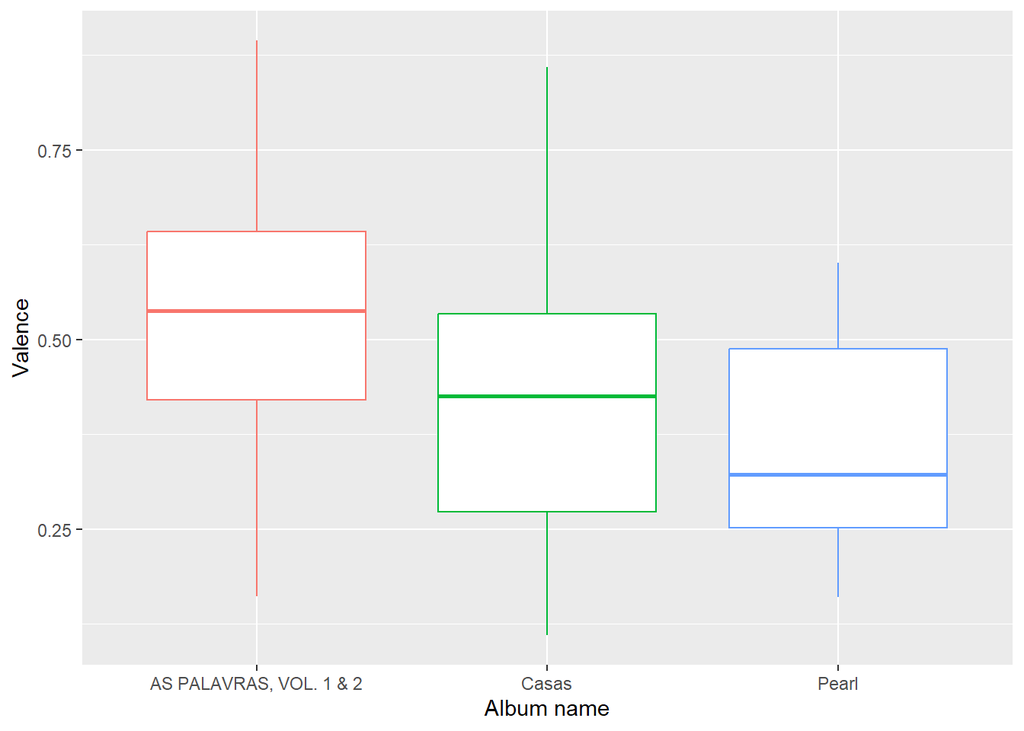

```r
# Change album_name from character to factor before plotting
df$album_name <- as.factor(df$album_name)
# Plot a boxplot
ggplot(df, aes(x=album_name, y=valence, color=album_name))+
  geom_boxplot()+
  labs(x="Album name", y="Valence")+
  theme(legend.position="none")
```

For valence, Pearl (2015) seems the most sad one. Indeed, as noted in the album introductions, this album contains songs filled with nostalgia and melancholy.

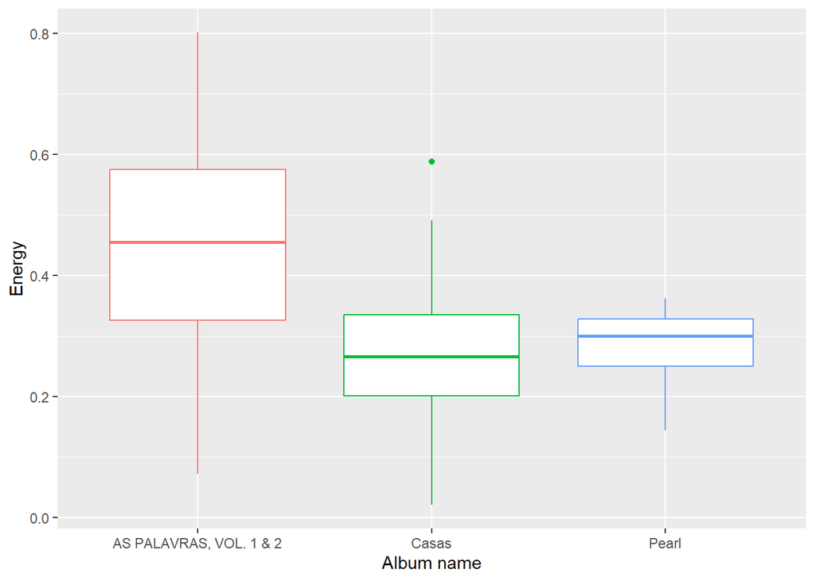

```r
ggplot(df, aes(x=album_name, y=energy, color=album_name)) +
  geom_boxplot() +
  labs(x="Album name", y="Energy") +
  theme(legend.position="none")
```

Pearl (2015) is a consistent album, as you can see, the songs’ range are in a narrow interval, and overall low in energy. Nonetheless, Casas (2018) surprisingly shows lower energy levels compared to Pearl.

## Rubel’s most danceable songs

```r
df |> slice_max(danceability, n=3) |> dplyr::select(track_name, album_name, album_release_year, danceability) |> knitr::kable(digits = 2)
```

| track_name | album_name | album_release_year | danceability |
| --- | --- | --- | --- |
| Sapato | Casas | 2018 | 0.83 |
| Rubelía | AS PALAVRAS, VOL. 1 & 2 | 2023 | 0.79 |
| Colégio | Casas | 2018 | 0.77 |

### Songs by Rubel with the most spoken words

```r
df |> slice_max(speechiness, n=3) |> dplyr::select(track_name, album_name, album_release_year, speechiness) |> knitr::kable(digits = 2)
```

| track_name | album_name | album_release_year | speechiness |
| --- | --- | --- | --- |
| Vinheta As Palavras II | AS PALAVRAS, VOL. 1 & 2 | 2023 | 0.31 |
| Batuque | Casas | 2018 | 0.30 |
| Rubelía | AS PALAVRAS, VOL. 1 & 2 | 2023 | 0.24 |

I think most people would disagree that “Rubelía” and “Batuque” are Rubel’s songs with the most spoken words… You can see that the two of them, in fact, have *no* spoken words.

[video not shown]

## Rubel’s songs classification

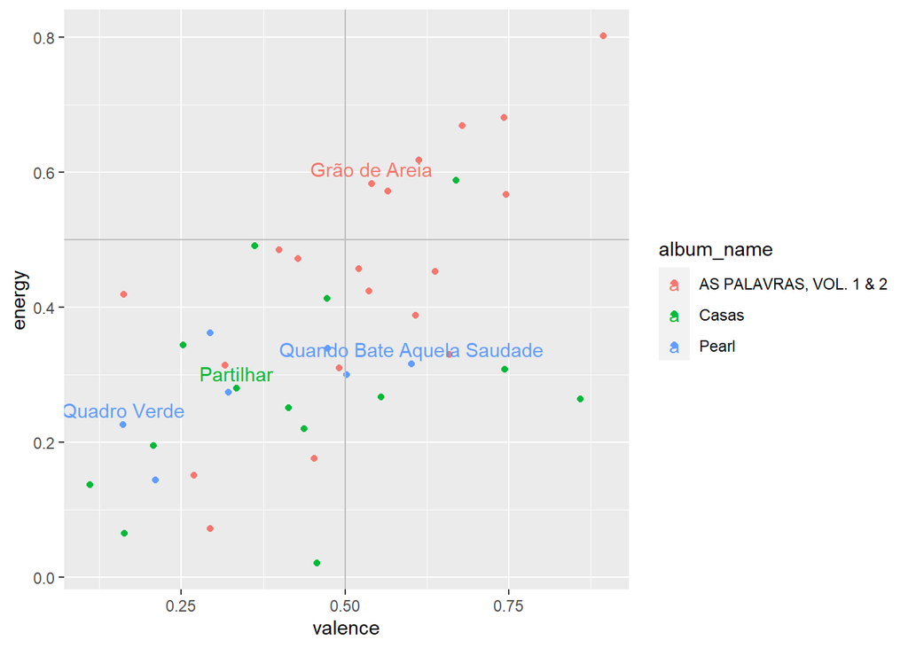

```r
subgroup <- df %>%
  filter(track_name %in% c("Quando Bate Aquela Saudade", "Partilhar", "Grão de Areia", "Quadro Verde"))

ggplot(df, aes(x = valence, y = energy, color = album_name)) +
  geom_point() +
  geom_hline(yintercept = 0.5, color = "grey") +
  geom_vline(xintercept = 0.5, color = "grey") +
  geom_text(data = subgroup, aes(label = track_name), vjust = -0.5)
```

The upper left square is *Angry*, the upper right is *Joyful*. The bottom left is *Sad* and the right one *Peaceful*. Most of his songs are sad. In his recent album, lots of them are also joyful. Interestingly, he has no angry songs.